# Big Data Analysis of Futures

September 27, 2017

## Quick Intro

- Machine Learning Engineer
- Masters in applied mathematics and statistics from Johns Hopkins University
- Bachelors in pure mathematics from the University of Pennsylvania
- Spent years working in Healthcare, Finance, and Telecommunications industries in roles spanning data analyst, software engineer, and data scientist
- Talk is based on my graduate thesis

## Problem Statement

How can we accurately predict trade volume?

- many trading algorithms depend on volume
- accurate volume predictions over a given interval allows traders to be more effective
- volume prediction increases trading strategy capacity, controls trading risk

How can we understand the relationships between trade volume and price volatility?

- new information on the market causes agents such as hedgers and speculators to trade until prices reach a revised equilibrium which then changes price and trading volume
- provides information on the efficiency of futures markets which regulators can then use to decide upon market restrictions

## About the Data

- Hundreds of millions of rows of futures trading in the form of order books
- Comes from the Chicago Mercantile Exchange (CME)
- Collected from May 2, 2016 to November 18, 2016
- Raw data from the CME included extended hours trading
- Fields included instrument name, maturity, date, time stamp, price, and quantity
- Futures were comprised of 22 financial instruments spanning six markets
  - foreign exchange, metal, energy, index, bond, and agriculture
- Trades were recorded roughly every half second
- Product defined as instrument/maturity pair
  - 149 products in total

## Raw Data

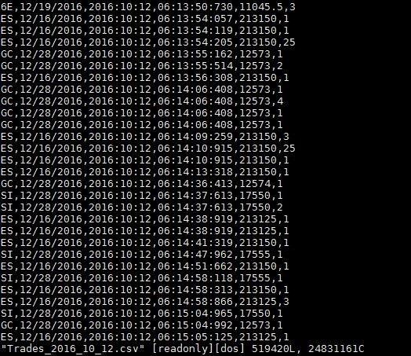

## Methods

## Processing Data

How can we efficiently process the overwhelming amount of data such that it is amenable to analysis?

We use Apache Spark to process the data

- What is Spark?
  - Spark is a fault-tolerant and general-purpose cluster computing system providing APIs in Java, Scala, Python, and R
- One node cluster set up
  - Linux Server
  - 32 cores
- Used Python API, i.e. Pyspark
- Used SparkSQL for parsing and reformating, treating raw data as table
- Data became manageable to visualize with pure python and analyze in R

## Regression Data Set

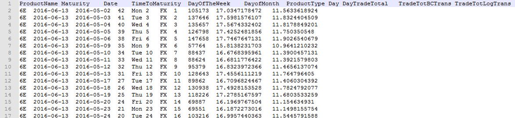

## Exploratory Data Analysis

## Checking for Normality

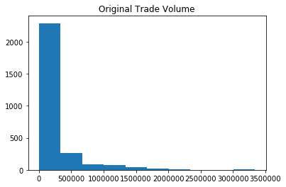

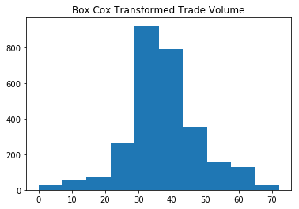

## Checking Normality at Market Level

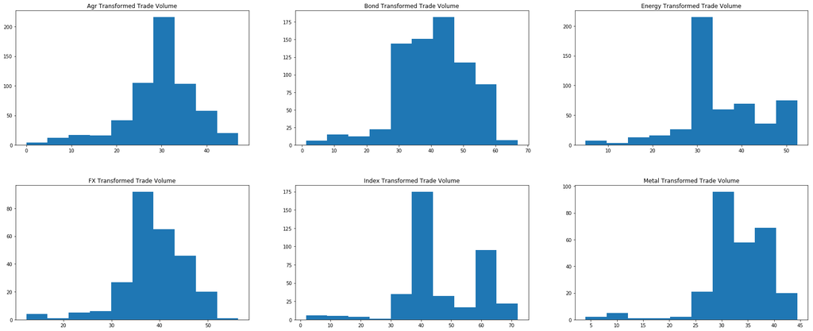

## Day Effects at Market Level

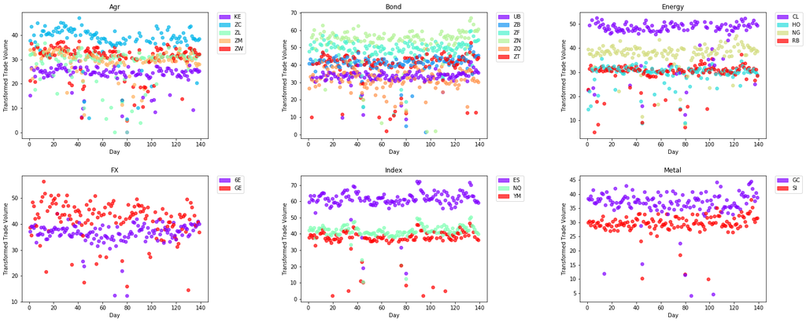

## Day of Month Effects at Market Level

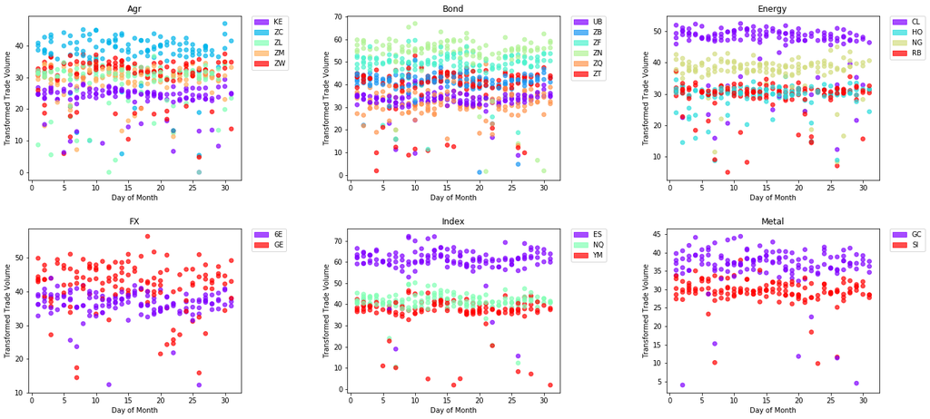

## Time to Maturity Effects at Market Level

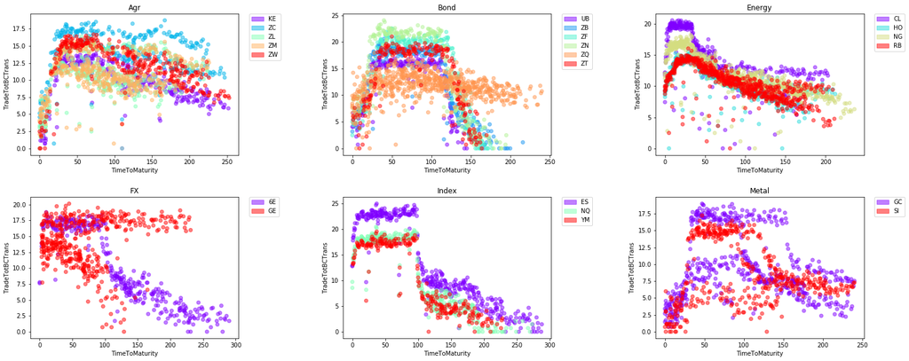

## Time to Maturity Effects at Instrument Level

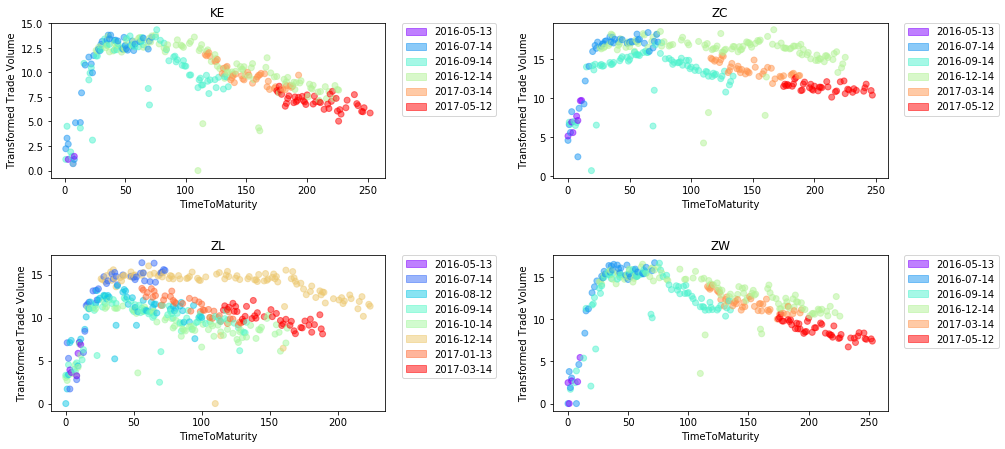

## Regression

## Spline Prediction

What is a spline?

- Spline basis functions are piecewise polynomials used in fitting curves which are linear in terms of the basis function.
- Cubic splines in particular have been found to have nice properties with good ability to fit nonlinear curves.
- Cubic splines are made to be smooth at the knots, endpoints of intervals on the x-axis
  - Force first and second derivatives of the function to agree at knots

## Use Penalized Spline in GAM

- Called a smoothing spline
- Penalty is integrated second derivative
- Cost function

  \(\sum_{i=1}^N [y_i-f(x_i)]^2 + \lambda \int f''(t)^2 dt\)
- GAM = Generalized Additive Model
  - Instead of:  
    \(E[Y|X_1, X_2,...,X_p]=\beta_0+\beta_1X_1+\beta_2X_2+...+\beta_pX_p\)
  - We have:  
    \(g(E[Y|X_1, X_2,...,X_p])=\beta_0+f(X_1)+f(X_2)+...+f(X_p)\), where g is the link function.

## Models

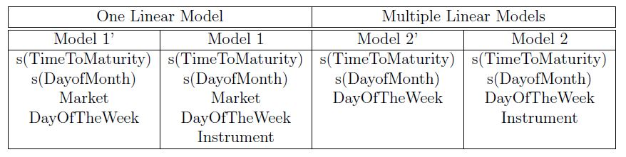

- One Model Paradigm: One model for all markets
- Multiple Model Paradigm: One model for each market
- Primes are before instrument is added
  - We want to know if knowing the instrument makes model better
  - "s" denotes spline basis function on predictor variable

## Regression Results

## Spline Curves

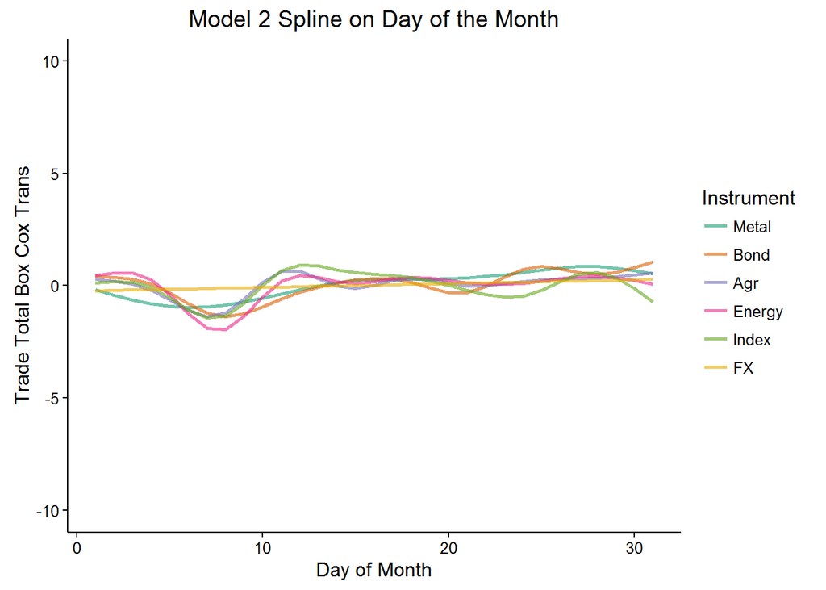

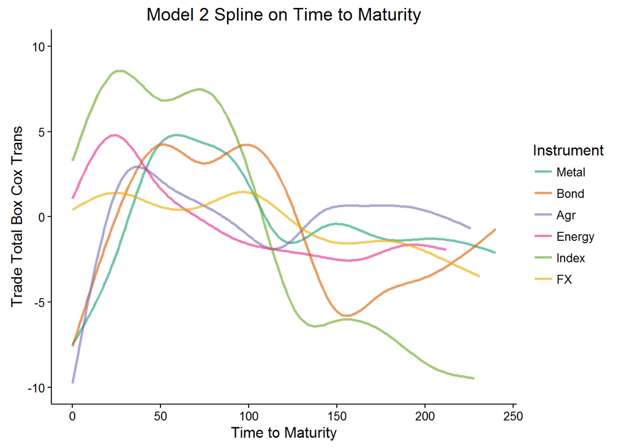

## Comparing All Models at Market Level

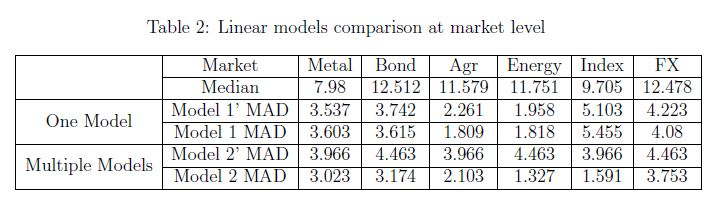

- Consider the best model
- Agriculture, energy,and index
  - Relative errors of 0.182, 0.113, and 0.164 respectively
- Metal, bond, and FX
  - Relative errors of 0.379, 0.254, and 0.301 respectively

## Comparing Models at Instrument Level

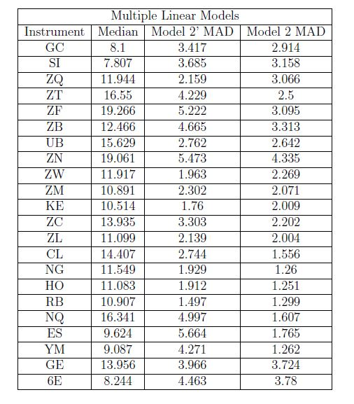

- Relative error is under .20 for most instruments.
- Exceptions are both metals (GC and SI) as on the market level, both FX instruments (6E and GE) as on the market level, and three bonds: 30 Day Fed Fund (ZQ), 30 Yr U.S. Treasury Bond (ZB), and 10Y Treasury Note (ZN).
- Relative errors are 0.360, 0.405, 0.2676, 0.459, 0.257, 0.266, and 0.227 respectively.

## Relationship Between Trade Volume and Price Volatility

## Trade Volume Data Set

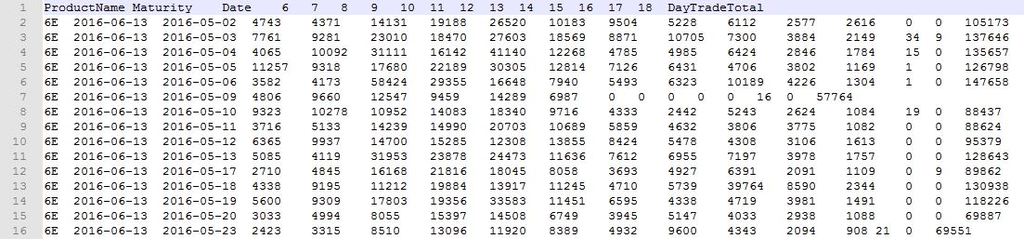

## Price Volatility Data Set

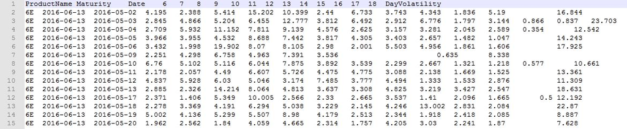

volatility measured with standard deviation

## Look at Active Trading period

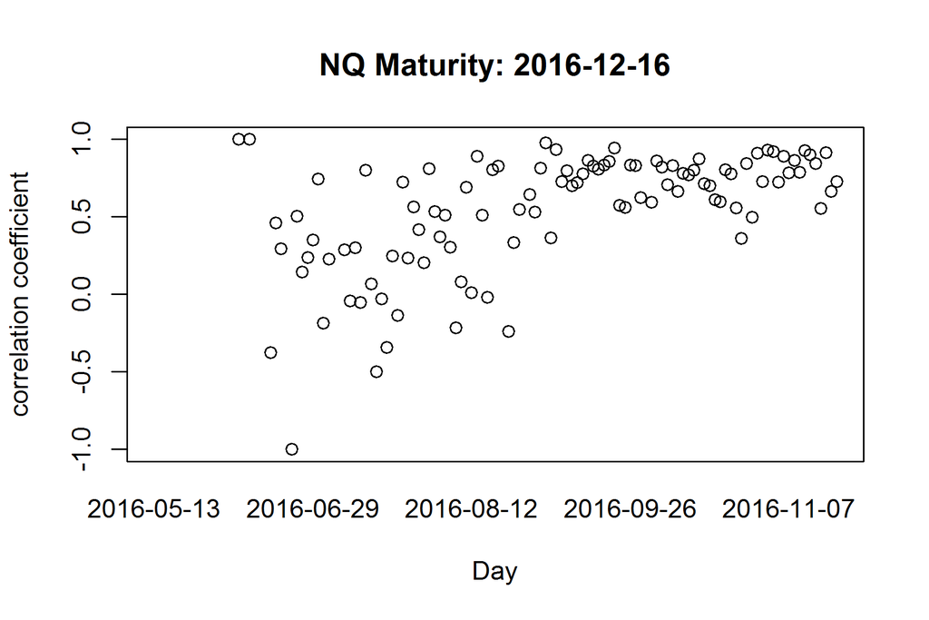

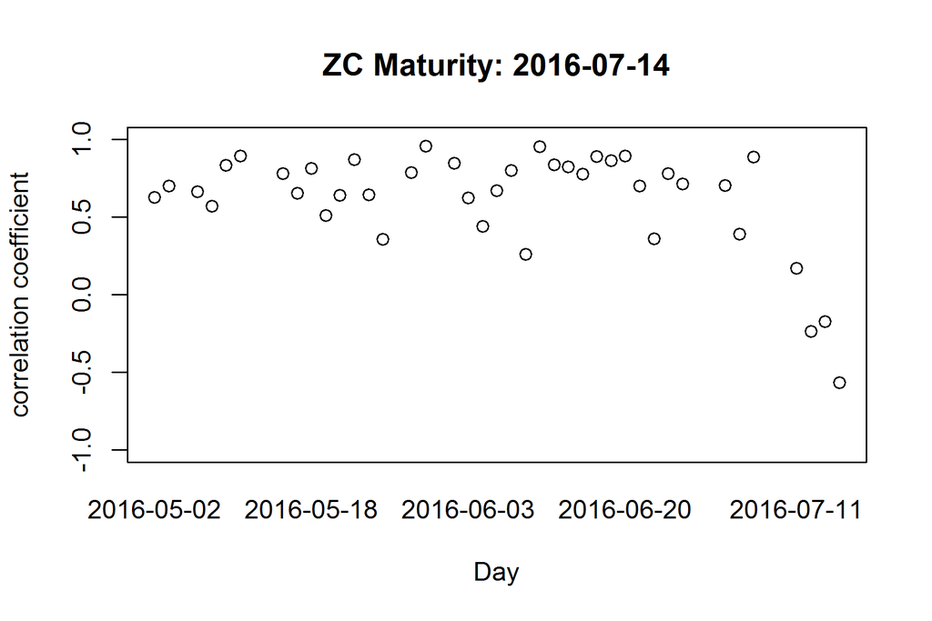

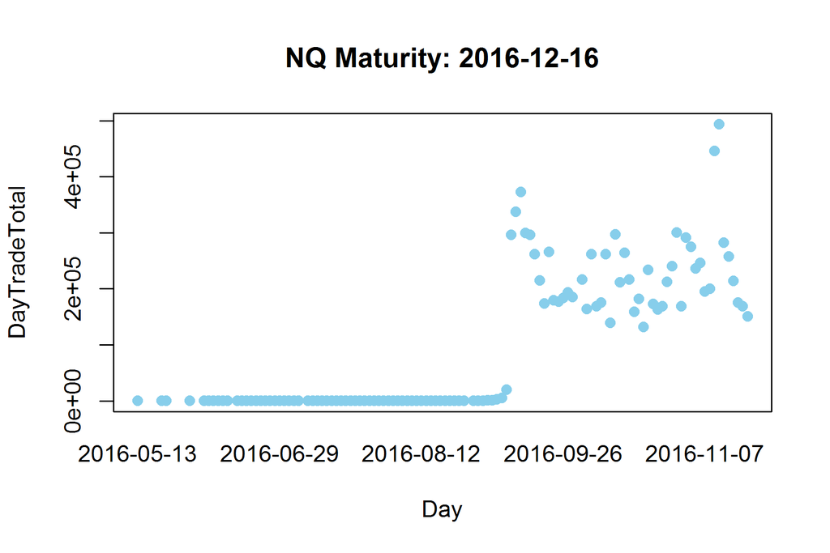

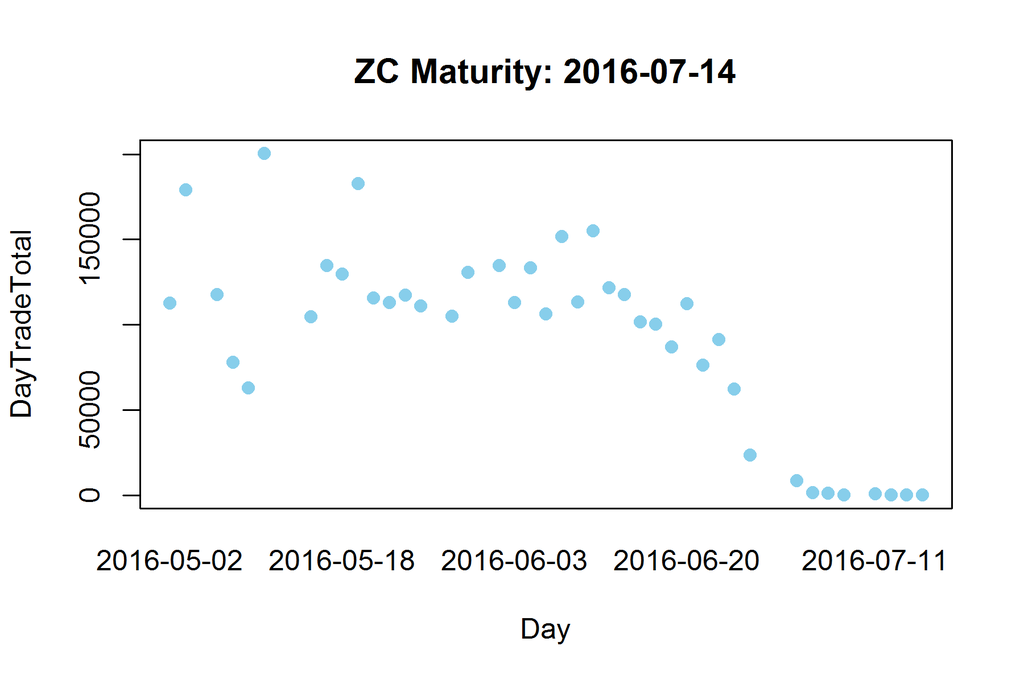

## Relationship Results

## Significant Products at FDR=.2

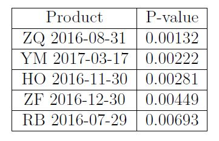

- 5 year treasury note (ZF)
- Rbob gasoline (RB)
- 30 Day Fed Fund (ZQ)
- Mini Dow Jones index (YM)
- Heating oil (HO)

## Significant Correlation Plots with Best Fit Line

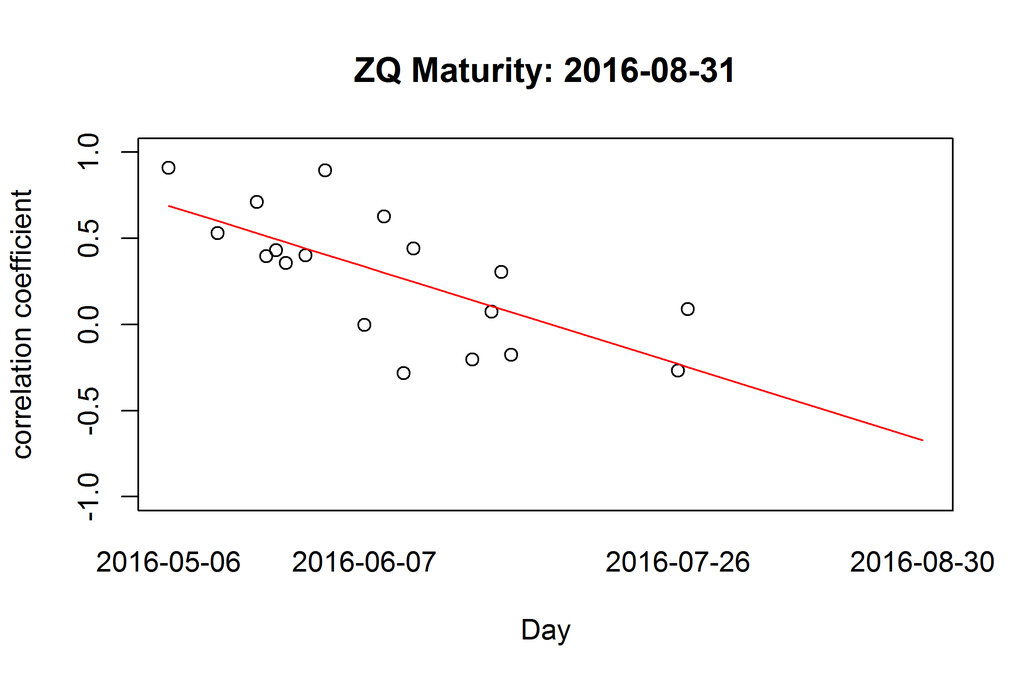

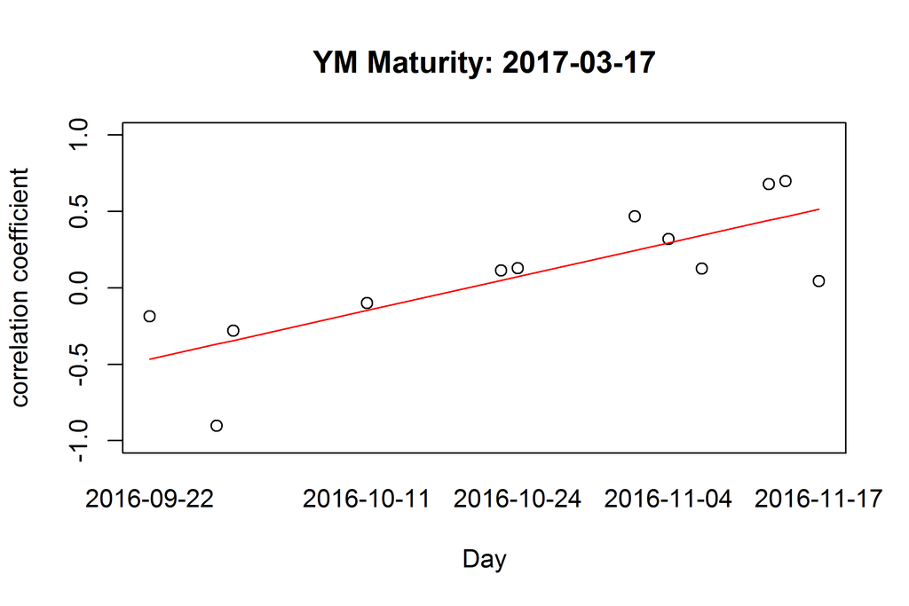

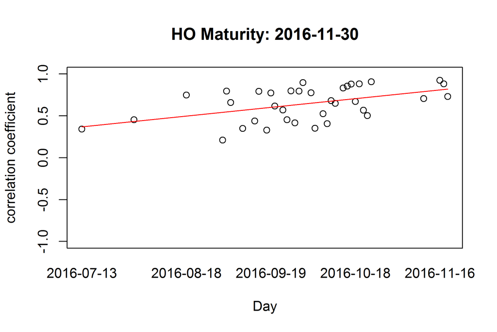

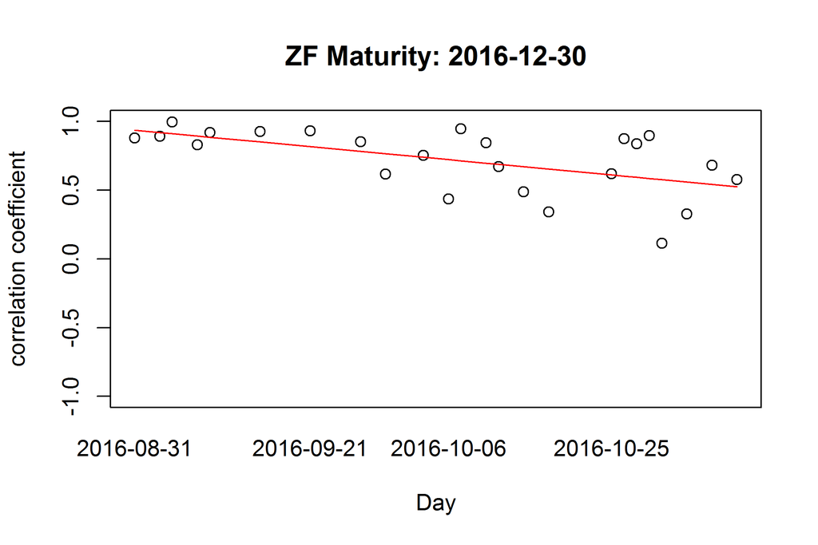

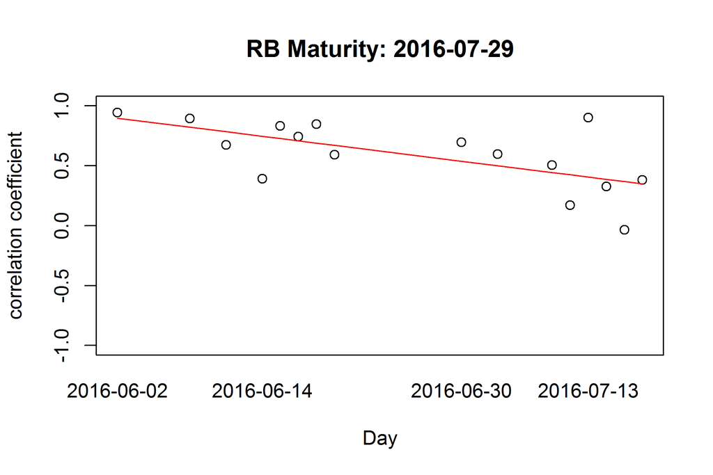

## Looking at Deemed Active Period

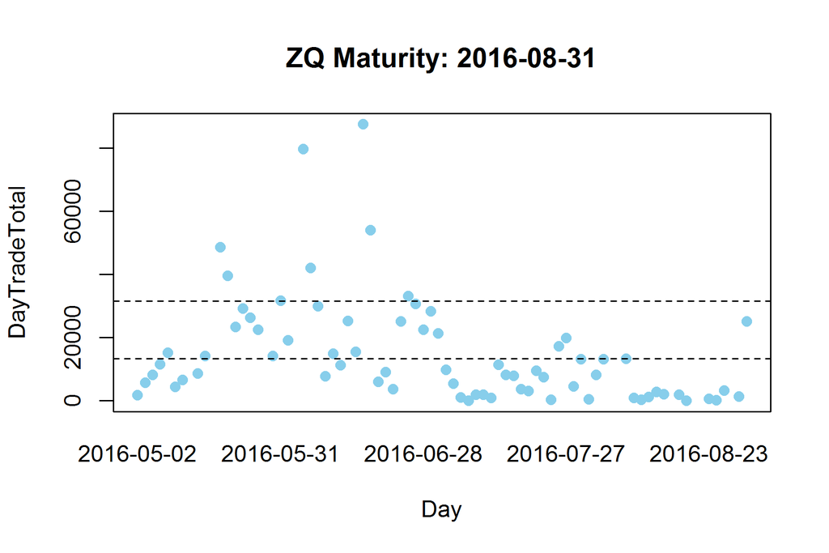

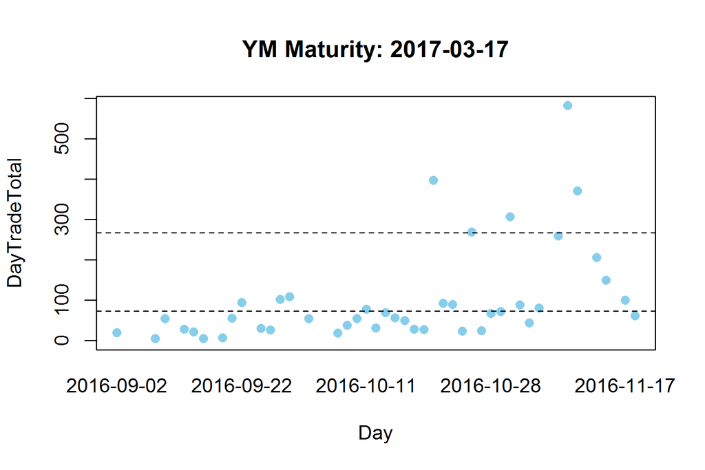

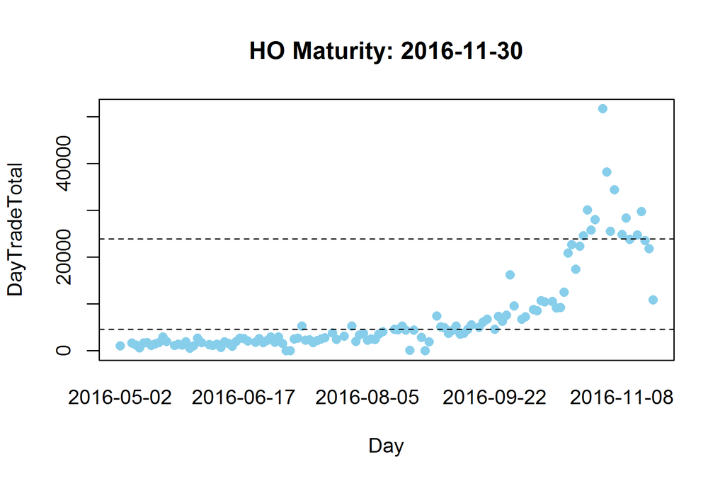

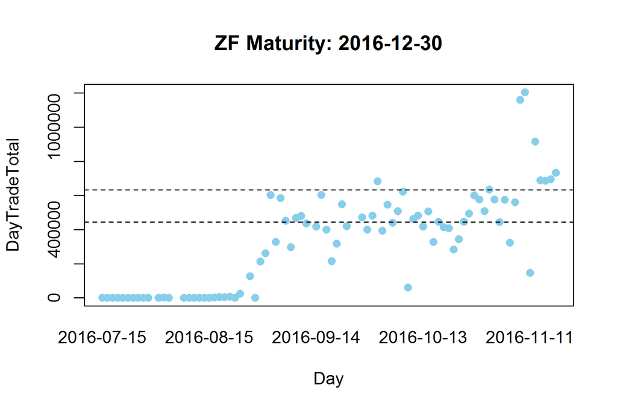

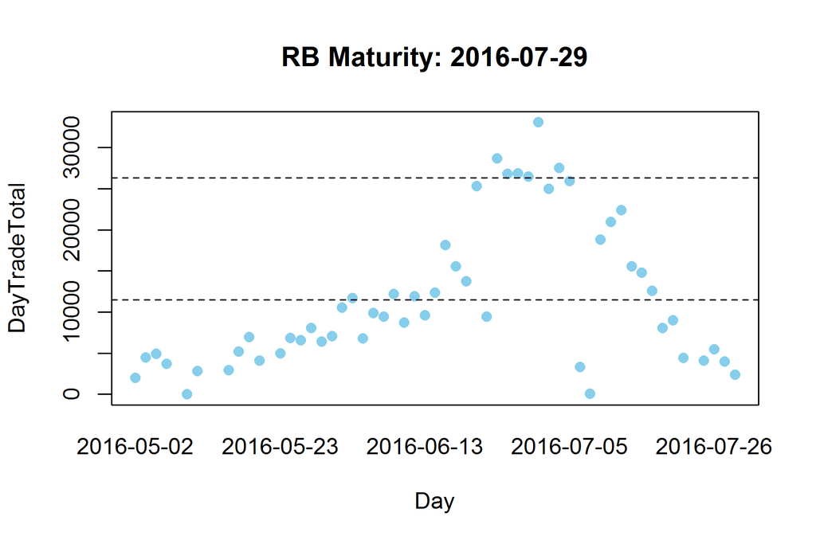

Dashes denote 60th-90th volume percentiles